# Compare base case curtailment vs CAISO 2016 curtailment data

- CAISO 2016 curtailment data downloaded from http://www.caiso.com/informed/Pages/ManagingOversupply.aspx
- data are in 5-min intervals; data aggregated to 1 hour intervals
- simulation data are from base case with scenario_name = 'western_scenario_Update01'

## Summary

Curtailment values from our simulations are at least 2 orders of magnitude smaller than the CAISO curtailment values (depending on what curtailment metric is being counted). The simulation's smaller values come from the combination of (1) much smaller curtailment values and (2) much less frequent curtailment. Although the CAISO demand ('Load') values are smaller than the simulation demand data (and smaller demand can lead to more curtailment), the difference is not large enough to explain the difference.

Possible sources of the differences include available energy forecast errors, ramp rate differences, non-physical (e.g., does not follow laws of physics) curtailment practices.

## Summary Stats

```python
stats.T.head(20)
```

|  | CAISO | SIM |
| --- | --- | --- |
| wind_curtailment_hours | 2437 | 10 |
| wind_curtailment_pc | 0.528571 | 0.000423049 |
| solar_curtailment_hours | 1801 | 6 |
| solar_curtailment_pc | 1.08735 | 5.50194e-05 |

## Summary Plots

```
(-67.57131319512007, 1486.5688902926418)
```

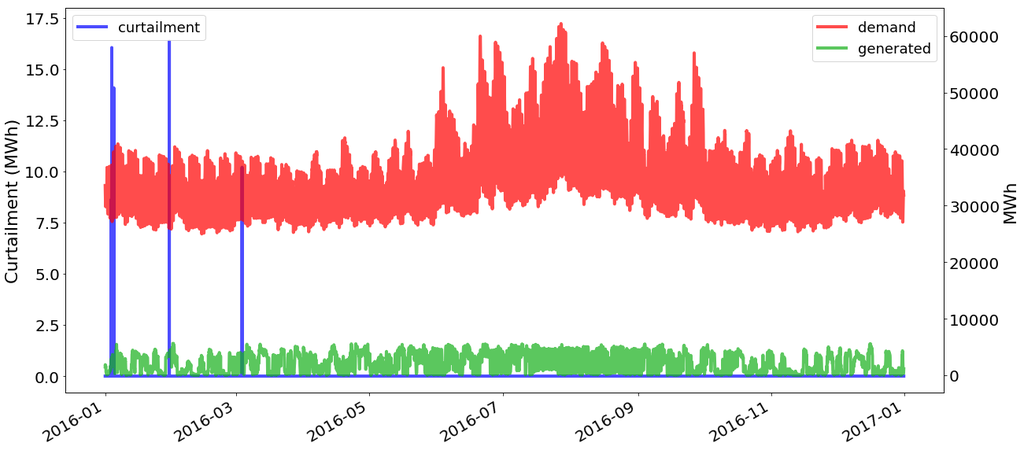

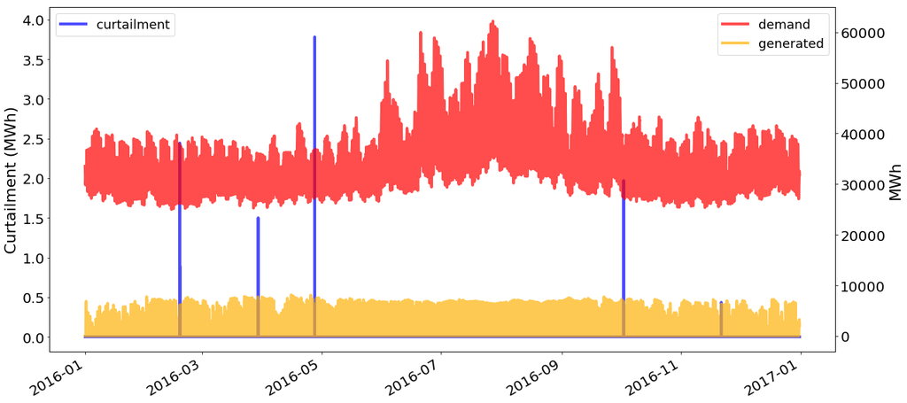

```python
##### SIM WIND
fig = plt.figure(figsize=(20, 10))
ax = fig.gca()
ax_twin = ax.twinx()

sim_wind[['curtailment']].plot(ax = ax, color = ['b'], alpha = 0.7, lw=4)
sim_wind[['demand','generated']].plot(ax = ax_twin, color = ['r', curtailment.grid.type2color['wind']], alpha = 0.7, lw=4)

ax.tick_params(which='both', labelsize=20)
#ax.grid(color='black', axis='y')
ax.set_xlabel('')
ax.set_ylabel('Curtailment (MWh)', fontsize=22)
ax.legend(loc='upper left', prop={'size': 18})
ax_twin.tick_params(which='both', labelsize=20)
ax_twin.set_ylabel('MWh', fontsize=22)
ax_twin.legend(loc='upper right', prop={'size': 18})
ax_twin.set_ylim(top=65000)
ax.set_ylim(top = 1.1*sim_wind['curtailment'].max())

##### CAISO WIND
fig = plt.figure(figsize=(20, 10))
ax = fig.gca()
ax_twin = ax.twinx()

data_h[['Wind Curtailment']].plot(ax = ax, color = ['b'], alpha = 0.7, lw=4)
data_h[['Load','Wind']].plot(ax = ax_twin, color = ['r',curtailment.grid.type2color['wind']], alpha = 0.7, lw=4)

ax.tick_params(which='both', labelsize=20)
#ax.grid(color='black', axis='y')
ax.set_xlabel('')
ax.set_ylabel('Curtailment (MWh)', fontsize=22)
ax.legend(loc='upper left', prop={'size': 18})
ax_twin.tick_params(which='both', labelsize=20)
ax_twin.set_ylabel('MWh', fontsize=22)
ax_twin.legend(loc='upper right', prop={'size': 18})
ax_twin.set_ylim(top=65000)
ax.set_ylim(top = 1.1*data_h['Wind Curtailment'].max())

##### SIM SOLAR
fig = plt.figure(figsize=(20, 10))
ax = fig.gca()
ax_twin = ax.twinx()

sim_solar[['curtailment']].plot(ax = ax, color = ['b'], alpha = 0.7, lw=4)
sim_solar[['demand','generated']].plot(ax = ax_twin, color = ['r', curtailment.grid.type2color['solar']], alpha = 0.7, lw=4)

ax.tick_params(which='both', labelsize=20)
#ax.grid(color='black', axis='y')
ax.set_xlabel('')
ax.set_ylabel('Curtailment (MWh)', fontsize=22)
ax.legend(loc='upper left', prop={'size': 18})
ax_twin.tick_params(which='both', labelsize=20)
ax_twin.set_ylabel('MWh', fontsize=22)
ax_twin.legend(loc='upper right', prop={'size': 18})
ax_twin.set_ylim(top=65000)
ax.set_ylim(top = 1.1*sim_solar['curtailment'].max())


##### CAISO SOLAR
fig = plt.figure(figsize=(20, 10))
ax = fig.gca()
ax_twin = ax.twinx()

data_h[['Solar Curtailment']].plot(ax = ax, color = ['b'], alpha = 0.7, lw=4)
data_h[['Load','Solar']].plot(ax = ax_twin, color = ['r',curtailment.grid.type2color['solar']], alpha = 0.7, lw=4)

ax.tick_params(which='both', labelsize=20)
#ax.grid(color='black', axis='y')
ax.set_xlabel('')
ax.set_ylabel('Curtailment (MWh)', fontsize=22)
ax.legend(loc='upper left', prop={'size': 18})
ax_twin.tick_params(which='both', labelsize=20)
ax_twin.set_ylabel('MWh', fontsize=22)
ax_twin.legend(loc='upper right', prop={'size': 18})
ax_twin.set_ylim(top=65000)
ax.set_ylim(top = 1.1*data_h['Solar Curtailment'].max())
```

[output not shown]

# Analysis details

```python
import pandas as pd
import matplotlib.pyplot as plt

from postreise.process import transferdata as td
from postreise.plot.analyze_pg import AnalyzePG as apg
from westernintnet.westernintnet import win_data

import numpy as np
import pandas as pd
#import seaborn; seaborn.set()
import os
import sys
sys.path.append("..")

%matplotlib inline
```

```python
od = td.OutputData()
```

```
Use  /Users/mlamherr/scenario_data/  to save/load local scenario data.
```

```python
def get_plant_id(zone, resource):
    plant_id = []
    if zone == 'Western':
        try:
            plant_id = win_data.genbus.groupby('type').get_group(resource).index.values.tolist()
        except KeyError:
            pass
    elif zone == 'California':
        CA = ['Bay Area', 'Central California', 'Northern California',
                'Southeast California', 'Southwest California']
        for load_zone in CA:
            try:
                plant_id += win_data.genbus.groupby(['ZoneName', 'type']).get_group(
                    (load_zone, resource)).index.values.tolist()
            except KeyError:
                pass
    else:
        try:
            plant_id = win_data.genbus.groupby(['ZoneName', 'type']).get_group(
                (zone, resource)).index.values.tolist()
        except KeyError:
            pass

    return plant_id
```

## Base Case

Multiperiod  
Solar power: SAM  
demand v3  
No multiplier for any of the generator in the grid

```python
win_data.read_demand_data('v3')
win_data.read_solar_data('sam')
win_data.read_wind_data()
```

```
Load demand data
Load solar data
Load wind data
```

```python
multiplier = pd.DataFrame({'multiplier': [1]*len(win_data.genbus)}, index=win_data.genbus.index.values)
```

```python
pg = od.get_data('western_scenario_Update01', 'PG')
```

### Base case curtailment plots

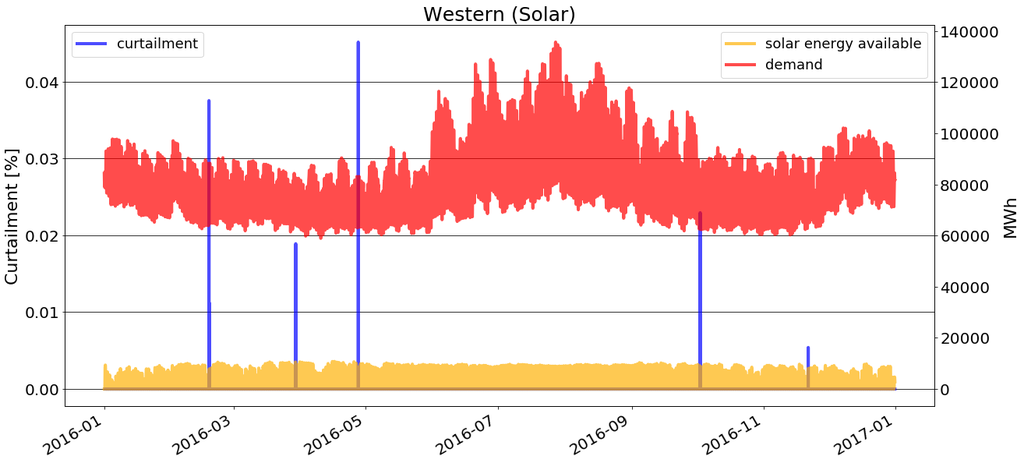

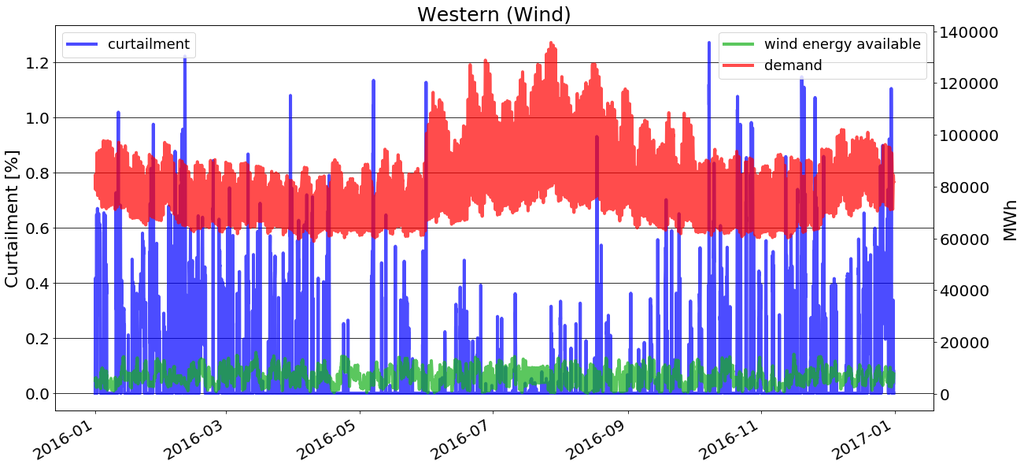

```
Maximum curtailment for solar generators in the Western Interconnection: 0 %
Maximum curtailment for wind generators in the Western Interconnection: 1 %
```

```python
curtailment = apg((pg, win_data, multiplier),
                  ('2016-01-01-00', '2016-12-31-23', 'local', 'H'), #try 'H' instead of 'D'
                  ['California', 'Western'],
                  ['solar', 'wind'],
                  'curtailment', normalize=False)
curtailment.get_plot(save=False)
data_curtailment = curtailment.get_data()
print("Maximum curtailment for solar generators in the Western Interconnection: %d %%" %
      round(data_curtailment['Western']['solar'].curtailment.max()))
print("Maximum curtailment for wind generators in the Western Interconnection: %d %%" %
      round(data_curtailment['Western']['wind'].curtailment.max()))
```

[output not shown]

```python
for zone in ['California', 'Western']:
    for resource in ['solar', 'wind']:
        available = data_curtailment[zone][resource].available.sum()
        generated = data_curtailment[zone][resource].generated.sum()
        curtailment = 100 * (available - generated) / available
        print("Curtailment %s/%s: %.8f %%" % (zone, resource, curtailment))
```

```
Curtailment California/solar: 0.00005502 %
Curtailment California/wind: 0.00042305 %
Curtailment Western/solar: 0.00004045 %
Curtailment Western/wind: 0.09203426 %
```

# CAISO DATA

```python
datadir = os.path.join('..','data/')
filename = 'ProductionAndCurtailmentsData-May1_2014-May31_2017.xlsx'
sheets = ['Production','Curtailments']
d0 = pd.read_excel(io=os.path.join(datadir, filename), header=0, sheet_name = sheets)
d1 = {}

for x in sheets:
    d0[x].index = pd.to_datetime(d0[x]['Date'])
    #d0[x]['Date2'] = d0[x].index.date
    d0[x]['Date2'] = pd.to_datetime(d0[x]['Date']).dt.date
    d0[x]['Year'] = pd.to_datetime(d0[x]['Date']).dt.year
    d1[x] = d0[x].loc[d0[x]['Year'] == 2016]

data = pd.merge(d1['Production'], d1['Curtailments'],
                how = 'left', on = ['Date2','Hour','Interval'],
               left_index=False)
data.index = pd.to_datetime(data['Date_x'])
data.index.rename('LocalTime',inplace=True)
data.drop(columns = ['Date2','Date_x','Date_y','Year_x','Year_y'], inplace=True)

# Remove duplicated time data
data = data[~data.index.duplicated(keep='first')]

# Remove NAs
data.fillna(value=0., inplace=True)

# Raw data are in 5 minute intervals; Resample to hourly data
data_h = data.resample('H').sum()/12.

# Estimate curtailment percent
data_h['solar_curtailed_pc'] = 100.* data_h['Solar Curtailment']/(1.+ data_h['Solar'] + data_h['Solar Curtailment'])
data_h['wind_curtailed_pc'] = 100.* data_h['Wind Curtailment']/(1. + data_h['Wind'] + data_h['Wind Curtailment'])
```

```python
data_h.describe()
```

|  | Hour | Interval | Load | Solar | Wind | Net Load | Renewables | Nuclear | Large Hydro | Imports | Generation | Thermal | Load Less (Generation+Imports) | Wind Curtailment | Solar Curtailment | solar_curtailed_pc | wind_curtailed_pc |
| --- | --- | --- | --- | --- | --- | --- | --- | --- | --- | --- | --- | --- | --- | --- | --- | --- | --- |
| count | 8784.000000 | 8784.000000 | 8784.000000 | 8784.000000 | 8784.000000 | 8784.000000 | 8784.000000 | 8784.000000 | 8784.000000 | 8784.000000 | 8784.000000 | 8784.000000 | 8784.000000 | 8784.000000 | 8784.000000 | 8784.000000 | 8784.000000 |
| mean | 12.499658 | 6.499260 | 26307.609732 | 2365.478286 | 1579.910879 | 22362.220567 | 5649.545460 | 2155.303667 | 2573.341911 | 7353.242826 | 18954.516801 | 8574.140848 | -0.149894 | 8.395319 | 26.003869 | 0.467200 | 1.402992 |
| std | 6.923123 | 0.069353 | 4811.607023 | 2926.286636 | 1158.786827 | 4544.751625 | 2975.185540 | 336.018563 | 936.080582 | 1419.500918 | 4720.630550 | 3494.218333 | 2.241156 | 27.988970 | 97.345407 | 1.694120 | 6.798858 |
| min | 0.000000 | 0.000000 | 0.000000 | 0.000000 | 0.000000 | 0.000000 | 0.000000 | 0.000000 | 0.000000 | 0.000000 | 0.000000 | 0.000000 | -90.277416 | 0.000000 | 0.000000 | 0.000000 | 0.000000 |
| 25% | 6.750000 | 6.500000 | 22785.440691 | 0.000000 | 475.587436 | 19162.205988 | 3258.433022 | 2269.086186 | 1844.105299 | 6421.105314 | 15679.131384 | 6054.915195 | -1.104805 | 0.000000 | 0.000000 | 0.000000 | 0.000000 |
| 50% | 12.500000 | 6.500000 | 25619.468163 | 135.711348 | 1451.842525 | 21534.568278 | 4831.141737 | 2274.821517 | 2512.462052 | 7428.584566 | 18342.131606 | 8098.721955 | -0.073839 | 0.000000 | 0.000000 | 0.000000 | 0.000000 |
| 75% | 18.250000 | 6.500000 | 28341.261239 | 5330.068314 | 2512.566128 | 24869.966137 | 8286.892776 | 2279.827035 | 3107.600685 | 8310.182723 | 20788.121449 | 10415.318081 | 0.890676 | 0.377917 | 0.000000 | 0.000000 | 0.028603 |
| max | 24.000000 | 6.500000 | 46007.718689 | 8527.943986 | 4675.857174 | 40875.382509 | 13578.897020 | 2292.517623 | 5793.094014 | 11597.116766 | 43172.641108 | 25628.360988 | 38.850259 | 568.085796 | 1351.426264 | 25.690971 | 83.891429 |

```python
print("Curtailment CAISO  - solar, hourly : ", data_h.describe().loc['mean']['solar_curtailed_pc'])
print("Curtailment CAISO  - wind, hourly  : ", data_h.describe().loc['mean']['wind_curtailed_pc'])
print()
print("CAISO to basecase solar ratio, hourly : ", data_h.describe().loc['mean']['solar_curtailed_pc']/0.000055)
print("CAISO to basecase wind ratio, hourly : ", data_h.describe().loc['mean']['wind_curtailed_pc']/0.000423)
print()

#Calculate curtailment fractions for the WHOLE YEAR: CAISO
for x in ['Wind','Solar']:
    available = data_h[x +' Curtailment'].sum() + data_h[x].sum()
    generated = data_h[x].sum()
    curtailment = 100 * (available - generated) / available
    print("CAISO Curtailment %s: %.8f %%" % (x, curtailment))

#Calculate curtailment fractions for the WHOLE YEAR: BASE CAEE 2016
for zone in ['California']:
    for resource in ['solar', 'wind']:
        available = data_curtailment[zone][resource].available.sum()
        generated = data_curtailment[zone][resource].generated.sum()
        curtailment = 100 * (available - generated) / available
        print("Simulation Curtailment %s/%s: %.8f %%" % (zone, resource, curtailment))
```

```
Curtailment CAISO  - solar, hourly :  0.46720040458002565
Curtailment CAISO  - wind, hourly  :  1.402991789172738

CAISO to basecase solar ratio, hourly :  8494.55281054592
CAISO to basecase wind ratio, hourly :  3316.765459037206

CAISO Curtailment Wind: 0.52857055 %
CAISO Curtailment Solar: 1.08735366 %
Simulation Curtailment California/solar: 0.00005502 %
Simulation Curtailment California/wind: 0.00042305 %
```

### Those are large differences! Do some sanity checks!

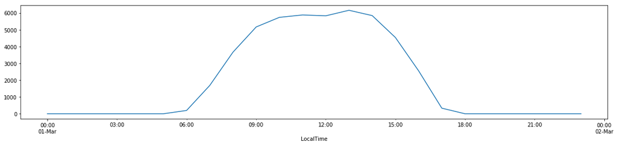

```python
# Checking time zones
data_h.loc['2016-03-01']['Solar'].plot(figsize=[20,4])
# Time zones are same
```

```python
data_curtailment['California']['solar'].describe()
```

|  | available | generated | demand | curtailment |
| --- | --- | --- | --- | --- |
| count | 8776.000000 | 8776.000000 | 8776.000000 | 4455.000000 |
| mean | 2282.017612 | 2282.016356 | 35259.668484 | 0.000043 |
| std | 2732.608809 | 2732.607185 | 6495.093090 | 0.001374 |
| min | 0.000000 | 0.000000 | 24994.535951 | 0.000000 |
| 25% | 0.000000 | 0.000000 | 30554.518221 | 0.000000 |
| 50% | 11.527147 | 11.527147 | 34302.134228 | 0.000000 |
| 75% | 5124.373069 | 5124.373069 | 37894.394379 | 0.000000 |
| max | 8160.348043 | 8160.348043 | 62183.408078 | 0.062544 |

```python
data_curtailment['California']['wind'].describe()
```

|  | available | generated | demand | curtailment |
| --- | --- | --- | --- | --- |
| count | 8776.000000 | 8776.000000 | 8776.000000 | 8776.000000 |
| mean | 2185.787897 | 2185.778650 | 35259.668484 | 0.000334 |
| std | 1661.375979 | 1661.372436 | 6495.093090 | 0.011981 |
| min | 0.984467 | 0.984467 | 24994.535951 | 0.000000 |
| 25% | 540.223645 | 540.223645 | 30554.518221 | 0.000000 |
| 50% | 1967.385032 | 1967.385032 | 34302.134228 | 0.000000 |
| 75% | 3705.050345 | 3705.050345 | 37894.394379 | 0.000000 |
| max | 5621.685315 | 5621.685315 | 62183.408078 | 0.586999 |

```python
data_h[['Solar','Wind','Load']].describe()
```

|  | Solar | Wind | Load |
| --- | --- | --- | --- |
| count | 8784.000000 | 8784.000000 | 8784.000000 |
| mean | 2365.478286 | 1579.910879 | 26307.609732 |
| std | 2926.286636 | 1158.786827 | 4811.607023 |
| min | 0.000000 | 0.000000 | 0.000000 |
| 25% | 0.000000 | 475.587436 | 22785.440691 |
| 50% | 135.711348 | 1451.842525 | 25619.468163 |
| 75% | 5330.068314 | 2512.566128 | 28341.261239 |
| max | 8527.943986 | 4675.857174 | 46007.718689 |

Aha, CAISO data has lower load than our simulation demand data; why is that?

- Compare with CISO EIA data; also compare
- demand obtained by multiplying CA 2016 population * demand per capita
- demand by multiplying CISO service population * demand per capita

Note that higher load means curtailment is less likely to happen. Demand vs solar/wind curtailment not likely linear function. Also, does demand include demand from houses with solar cells?

```python
ba_2016 = pd.read_csv(datadir + 'ba_2016.csv', header=0, index_col='UTC Time')
```

```python
ba_2016.columns
```

```
Index(['AVA', 'AZPS', 'BANC', 'BPAT', 'CHPD', 'CISO', 'DEAA', 'DOPD', 'EPE',
       'GCPD', 'GRID', 'GRIF', 'GRMA', 'GWA', 'HGMA', 'IID', 'IPCO', 'LDWP',
       'NEVP', 'NWMT', 'PACE', 'PACW', 'PGE', 'PNM', 'PSCO', 'PSEI', 'SCL',
       'SRP', 'TEPC', 'TIDC', 'TPWR', 'WACM', 'WALC', 'WAUW', 'WWA'],
      dtype='object')
```

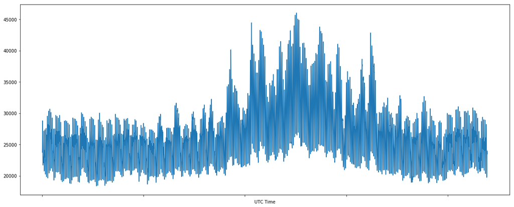

```python
ba_2016['CISO'].plot(figsize=[20,8])
```

```python
ba_2016['CISO'].describe()
```

```
count     8784.000000
mean     26301.709244
std       4810.015953
min      18356.000000
25%      22773.750000
50%      25602.500000
75%      28338.750000
max      46005.000000
Name: CISO, dtype: float64
```

So ba_2016 CISO data is consistent with downloaded data; our simulation curtailment data should only look at the CA population belonging to CAISO, not whole CA; is this possible?

```python
#Ratio of demand from simulation vs CAISO load
simulation_demand_mean = data_curtailment['California']['solar'].describe().loc['mean']['demand']
caiso_load_mean = data_h.describe().loc['mean']['Load']
demand_ratio = caiso_load_mean/simulation_demand_mean
print('mean simulation CA demand = ', simulation_demand_mean)
print('mean CAISO load = ', caiso_load_mean)
print('simulation CA demand/CAISO load = ', demand_ratio)
print()
print('According to https://en.wikipedia.org/wiki/California_Independent_System_Operator, CAISO manages about 80% of CA\'s electric flow')
```

```
mean simulation CA demand =  35259.66848356119
mean CAISO load =  26307.609732384117
simulation CA demand/CAISO load =  0.7461105241148052

According to https://en.wikipedia.org/wiki/California_Independent_System_Operator, CAISO manages about 80% of CA's electric flow
```

#### Do we overestimate demand? Get CA population and multiply by demand per capita

- demand per capita used in grid construction (Gegner et al 2016, Birchfeld et al 2016) is 2.01kW per person (summer demand from Eastern US population)
- CA 2016 population is 39.3M
- Answer - both simulation and CA demand load values are in the right ballpark, and less than expected demand based on Eastern summer data (CA has dryer summers than Eastern US, lower humidity means less air-conditioning; CA load is about 75% of simulation demand, but CAISO says they manage ~80% of CA electric flow.

```python
#Expected CA demand
expected_demand = 2.01e3 * 39.3e6
print('expected demand based on estimated Eastern per capita = ', expected_demand/1e6, ' MWh')
print('Note the per capita number is based on peak East Coast summer demand.')
```

```
expected demand based on estimated Eastern per capita =  78993.0  MWh
Note the per capita number is based on peak East Coast summer demand.
```

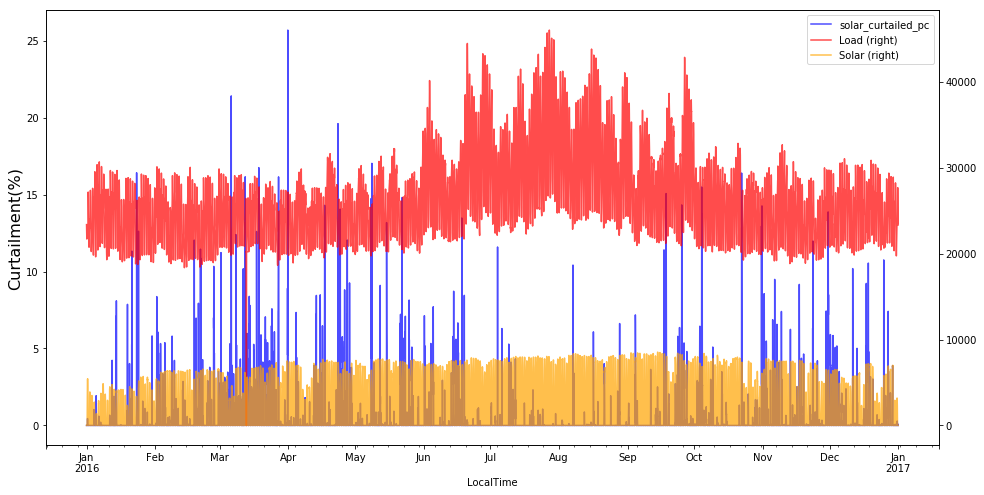

```python
#Make plots
curtailment = apg((pg, win_data, multiplier),
                  ('2016-01-01-00', '2016-12-31-23', 'local', 'H'), #try 'H' instead of 'D'
                  ['California'],
                  ['solar'],
                  'curtailment', normalize=False)
#curtailment.get_plot(save=False)
#data_h[['solar_curtailed_pc','Solar','Load']].plot(figsize=[16,8], secondary_y=['Solar','Load'])

caiso_solar_plot = data_h[['solar_curtailed_pc','Load','Solar']].plot(figsize=[16,8],
                                                                      secondary_y=['Solar','Load'],
                                                                      color=['b','r','orange'],
                                                                      alpha=0.7
                                                                     )
caiso_solar_plot.set_ylabel('Curtailment(%)', fontsize=16)
```

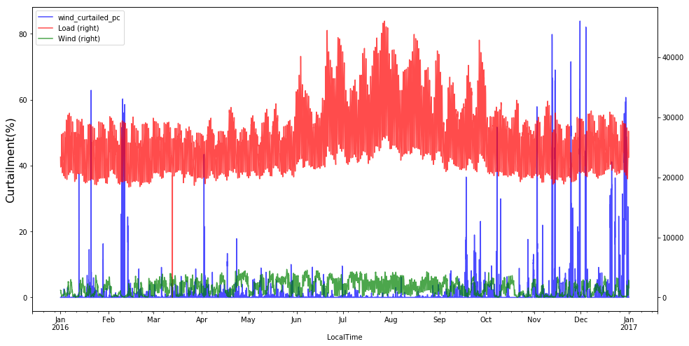

```python
curtailment = apg((pg, win_data, multiplier),
                  ('2016-01-01-00', '2016-12-31-23', 'local', 'H'), #try 'H' instead of 'D'
                  ['California'],
                  ['wind'],
                  'curtailment', normalize=False)
#curtailment.get_plot(save=False)
caiso_wind_plot = data_h[['wind_curtailed_pc','Load','Wind']].plot(figsize=[16,8],
                                                                   secondary_y=['Wind','Load'],
                                                                   color = ['b','r','g'],
                                                                   alpha = 0.7
                                                                  )
caiso_wind_plot.set_ylabel('Curtailment(%)', fontsize = 16)
```

```python
data_h[['Solar','solar_curtailed_pc','Wind','wind_curtailed_pc']].describe()
```

|  | Solar | solar_curtailed_pc | Wind | wind_curtailed_pc |
| --- | --- | --- | --- | --- |
| count | 8784.000000 | 8784.000000 | 8784.000000 | 8784.000000 |
| mean | 2365.478286 | 0.467200 | 1579.910879 | 1.402992 |
| std | 2926.286636 | 1.694120 | 1158.786827 | 6.798858 |
| min | 0.000000 | 0.000000 | 0.000000 | 0.000000 |
| 25% | 0.000000 | 0.000000 | 475.587436 | 0.000000 |
| 50% | 135.711348 | 0.000000 | 1451.842525 | 0.000000 |
| 75% | 5330.068314 | 0.000000 | 2512.566128 | 0.028603 |
| max | 8527.943986 | 25.690971 | 4675.857174 | 83.891429 |

```python
#Table summary
sim_solar = data_curtailment['California']['solar'].copy()
sim_wind = data_curtailment['California']['wind'].copy()
```

```python
sim_solar.fillna(0, inplace=True)
sim_wind.fillna(0, inplace=True)
```

```python
col_names = ['wind_curtailment_hours','wind_curtailment_pc',
            'solar_curtailment_hours','solar_curtailment_pc'
           ]
stats = pd.DataFrame(columns = col_names, index = ['CAISO','SIM'])

stats.loc['CAISO']['wind_curtailment_hours'] = data_h.loc[data_h['Wind Curtailment']>0].describe().loc['count']['Wind Curtailment']
stats.loc['CAISO']['solar_curtailment_hours'] = data_h.loc[data_h['Solar Curtailment']>0].describe().loc['count']['Solar Curtailment']

stats.loc['SIM']['wind_curtailment_hours'] = sim_wind.loc[sim_wind['curtailment']>0].describe().loc['count']['curtailment']
stats.loc['SIM']['solar_curtailment_hours'] = sim_solar.loc[sim_solar['curtailment']>0].describe().loc['count']['curtailment']

#Calculate curtailment fractions for the WHOLE YEAR: CAISO
for x in ['Wind','Solar']:
    available = data_h[x +' Curtailment'].sum() + data_h[x].sum()
    generated = data_h[x].sum()
    curtailment = 100 * (available - generated) / available
    stats.loc['CAISO'][x.lower() + '_curtailment_pc'] = curtailment
    print("CAISO Curtailment %s: %.8f %%" % (x, curtailment))

#Calculate curtailment fractions for the WHOLE YEAR: BASE CAEE 2016
for zone in ['California']:
    for resource in ['solar', 'wind']:
        available = data_curtailment[zone][resource].available.sum()
        generated = data_curtailment[zone][resource].generated.sum()
        curtailment = 100 * (available - generated) / available
        stats.loc['SIM'][resource + '_curtailment_pc'] = curtailment
        print("Simulation Curtailment %s/%s: %.8f %%" % (zone, resource, curtailment))
```

```
CAISO Curtailment Wind: 0.52857055 %
CAISO Curtailment Solar: 1.08735366 %
Simulation Curtailment California/solar: 0.00005502 %
Simulation Curtailment California/wind: 0.00042305 %
```

```python
stats.T.head(20)
```

|  | CAISO | SIM |
| --- | --- | --- |
| wind_curtailment_hours | 2437 | 10 |
| wind_curtailment_pc | 0.528571 | 0.000423049 |
| solar_curtailment_hours | 1801 | 6 |
| solar_curtailment_pc | 1.08735 | 5.50194e-05 |

```python
#Calculate curtailment fractions for the WHOLE YEAR: CAISO
for x in ['Wind','Solar']:
    available = data_h[x +' Curtailment'].sum() + data_h[x].sum()
    generated = data_h[x].sum()
    curtailment = 100 * (available - generated) / available
    print("CAISO Curtailment %s: %.8f %%" % (x, curtailment))
```

```
CAISO Curtailment Wind: 0.52857055 %
CAISO Curtailment Solar: 1.08735366 %
```

```python
#Calculate curtailment fractions for the WHOLE YEAR: BASE CASE
for zone in ['California']:
    for resource in ['solar', 'wind']:
        available = data_curtailment[zone][resource].available.sum()
        generated = data_curtailment[zone][resource].generated.sum()
        curtailment = 100 * (available - generated) / available
        print("Simulation Curtailment %s/%s: %.8f %%" % (zone, resource, curtailment))
```

```
Simulation Curtailment California/solar: 0.00005502 %
Simulation Curtailment California/wind: 0.00042305 %
```

```python
curtailment = apg((pg, win_data, multiplier),
                  ('2016-01-01-00', '2016-12-31-23', 'local', 'H'), #try 'H' instead of 'D'
                  ['California'],
                  ['solar'],
                  'curtailment', normalize=False)



fig = plt.figure(figsize=(20, 10))
ax = fig.gca()
ax_twin = ax.twinx()

data_h[['Solar Curtailment']].plot(ax = ax, color = ['b'], alpha = 0.7, lw=4)
data_h[['Load','Solar']].plot(ax = ax_twin, color = ['r',curtailment.grid.type2color['solar']], alpha = 0.7, lw=4)

ax.tick_params(which='both', labelsize=20)
#ax.grid(color='black', axis='y')
ax.set_xlabel('')
ax.set_ylabel('Curtailment (MWh)', fontsize=22)
ax.legend(loc='upper left', prop={'size': 18})
ax_twin.tick_params(which='both', labelsize=20)
ax_twin.set_ylabel('MWh', fontsize=22)
ax_twin.legend(loc='upper right', prop={'size': 18})
ax_twin.set_ylim(top=65000)
ax.set_ylim(top = 1.1*data_h['Solar Curtailment'].max())
```

[output not shown]

```
(-67.57131319512007, 1486.5688902926418)
```

```python
curtailment = apg((pg, win_data, multiplier),
                  ('2016-01-01-00', '2016-12-31-23', 'local', 'H'), #try 'H' instead of 'D'
                  ['California'],
                  ['wind'],
                  'curtailment', normalize=False)



fig = plt.figure(figsize=(20, 10))
ax = fig.gca()
ax_twin = ax.twinx()

data_h[['Wind Curtailment']].plot(ax = ax, color = ['b'], alpha = 0.7, lw=4)
data_h[['Load','Wind']].plot(ax = ax_twin, color = ['r',curtailment.grid.type2color['wind']], alpha = 0.7, lw=4)

ax.tick_params(which='both', labelsize=20)
#ax.grid(color='black', axis='y')
ax.set_xlabel('')
ax.set_ylabel('Curtailment (MWh)', fontsize=22)
ax.legend(loc='upper left', prop={'size': 18})
ax_twin.tick_params(which='both', labelsize=20)
ax_twin.set_ylabel('MWh', fontsize=22)
ax_twin.legend(loc='upper right', prop={'size': 18})
ax_twin.set_ylim(top=65000)
ax.set_ylim(top = 1.1*data_h['Wind Curtailment'].max())
```

[output not shown]

```
(-28.40428980697837, 624.8943757535242)
```

Plot energy generated for simulations (can compare with CAISO, since that's what CAISO has) and absolute curtailment values

```python
sim_solar.head()
```

| US/Pacific | available | generated | demand | curtailment |
| --- | --- | --- | --- | --- |
| 2016-01-01 00:00:00-08:00 | 0.0 | 0.0 | 33550.973256 | 0.0 |
| 2016-01-01 01:00:00-08:00 | 0.0 | 0.0 | 32429.926405 | 0.0 |
| 2016-01-01 02:00:00-08:00 | 0.0 | 0.0 | 31584.648606 | 0.0 |
| 2016-01-01 03:00:00-08:00 | 0.0 | 0.0 | 30686.602273 | 0.0 |
| 2016-01-01 04:00:00-08:00 | 0.0 | 0.0 | 30059.352177 | 0.0 |

```python
sim_wind.head()
```

| US/Pacific | available | generated | demand | curtailment |
| --- | --- | --- | --- | --- |
| 2016-01-01 00:00:00-08:00 | 1494.611638 | 1494.611638 | 33550.973256 | 0.0 |
| 2016-01-01 01:00:00-08:00 | 1866.723617 | 1866.723617 | 32429.926405 | 0.0 |
| 2016-01-01 02:00:00-08:00 | 1713.825579 | 1713.825579 | 31584.648606 | 0.0 |
| 2016-01-01 03:00:00-08:00 | 1590.504974 | 1590.504974 | 30686.602273 | 0.0 |
| 2016-01-01 04:00:00-08:00 | 1418.199830 | 1418.199830 | 30059.352177 | 0.0 |

```python
sim_solar.rename(columns = {'curtailment':'curtailment_pc'}, inplace = True)
sim_wind.rename(columns = {'curtailment':'curtailment_pc'}, inplace = True)
```

```python
sim_solar['curtailment'] = sim_solar['available'] - sim_solar['generated']
sim_wind['curtailment'] = sim_wind['available'] - sim_wind['generated']
```

Wind Plots

```
(-0.8180293747431051, 17.996646120204197)
```

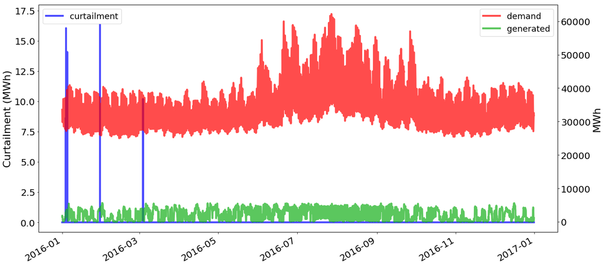

```python
##### SIM
fig = plt.figure(figsize=(20, 10))
ax = fig.gca()
ax_twin = ax.twinx()

sim_wind[['curtailment']].plot(ax = ax, color = ['b'], alpha = 0.7, lw=4)
sim_wind[['demand','generated']].plot(ax = ax_twin, color = ['r', curtailment.grid.type2color['wind']], alpha = 0.7, lw=4)

ax.tick_params(which='both', labelsize=20)
#ax.grid(color='black', axis='y')
ax.set_xlabel('')
ax.set_ylabel('Curtailment (MWh)', fontsize=22)
ax.legend(loc='upper left', prop={'size': 18})
ax_twin.tick_params(which='both', labelsize=20)
ax_twin.set_ylabel('MWh', fontsize=22)
ax_twin.legend(loc='upper right', prop={'size': 18})
ax_twin.set_ylim(top=65000)
ax.set_ylim(top = 1.1*sim_wind['curtailment'].max())
```

```python
##### CAISO
fig = plt.figure(figsize=(20, 10))
ax = fig.gca()
ax_twin = ax.twinx()

data_h[['Wind Curtailment']].plot(ax = ax, color = ['b'], alpha = 0.7, lw=4)
data_h[['Load','Wind']].plot(ax = ax_twin, color = ['r',curtailment.grid.type2color['wind']], alpha = 0.7, lw=4)

ax.tick_params(which='both', labelsize=20)
#ax.grid(color='black', axis='y')
ax.set_xlabel('')
ax.set_ylabel('Curtailment (MWh)', fontsize=22)
ax.legend(loc='upper left', prop={'size': 18})
ax_twin.tick_params(which='both', labelsize=20)
ax_twin.set_ylabel('MWh', fontsize=22)
ax_twin.legend(loc='upper right', prop={'size': 18})
ax_twin.set_ylim(top=65000)
ax.set_ylim(top = 1.1*data_h['Wind Curtailment'].max())
```

[output not shown]

```
(-28.40428980697837, 624.8943757535242)
```

Solar Plots

```
(-0.18914620454083889, 4.161216393066025)
```

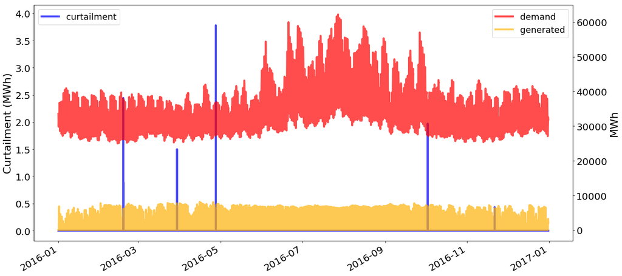

```python
##### SIM
fig = plt.figure(figsize=(20, 10))
ax = fig.gca()
ax_twin = ax.twinx()

sim_solar[['curtailment']].plot(ax = ax, color = ['b'], alpha = 0.7, lw=4)
sim_solar[['demand','generated']].plot(ax = ax_twin, color = ['r', curtailment.grid.type2color['solar']], alpha = 0.7, lw=4)

ax.tick_params(which='both', labelsize=20)
#ax.grid(color='black', axis='y')
ax.set_xlabel('')
ax.set_ylabel('Curtailment (MWh)', fontsize=22)
ax.legend(loc='upper left', prop={'size': 18})
ax_twin.tick_params(which='both', labelsize=20)
ax_twin.set_ylabel('MWh', fontsize=22)
ax_twin.legend(loc='upper right', prop={'size': 18})
ax_twin.set_ylim(top=65000)
ax.set_ylim(top = 1.1*sim_solar['curtailment'].max())
```

```python
#Solar plots
fig = plt.figure(figsize=(20, 10))
ax = fig.gca()
ax_twin = ax.twinx()

data_h[['Solar Curtailment']].plot(ax = ax, color = ['b'], alpha = 0.7, lw=4)
data_h[['Load','Solar']].plot(ax = ax_twin, color = ['r',curtailment.grid.type2color['solar']], alpha = 0.7, lw=4)

ax.tick_params(which='both', labelsize=20)
#ax.grid(color='black', axis='y')
ax.set_xlabel('')
ax.set_ylabel('Curtailment (MWh)', fontsize=22)
ax.legend(loc='upper left', prop={'size': 18})
ax_twin.tick_params(which='both', labelsize=20)
ax_twin.set_ylabel('MWh', fontsize=22)
ax_twin.legend(loc='upper right', prop={'size': 18})
ax_twin.set_ylim(top=65000)
ax.set_ylim(top = 1.1*data_h['Solar Curtailment'].max())
```

[output not shown]

```
(-67.57131319512007, 1486.5688902926418)
```

```python
data_h.head()
```

| LocalTime | Hour | Interval | Load | Solar | Wind | Net Load | Renewables | Nuclear | Large Hydro | Imports | Generation | Thermal | Load Less (Generation+Imports) | Wind Curtailment | Solar Curtailment | solar_curtailed_pc | wind_curtailed_pc |
| --- | --- | --- | --- | --- | --- | --- | --- | --- | --- | --- | --- | --- | --- | --- | --- | --- | --- |
| 2016-01-01 00:00:00 | 1.0 | 6.5 | 23370.164472 | 0.0 | 1182.616614 | 22187.547858 | 2855.162872 | 2281.659202 | 984.972462 | 6470.239276 | 16899.453137 | 10777.658601 | 0.472059 | 0.0 | 0.0 | 0.0 | 0.0 |
| 2016-01-01 01:00:00 | 2.0 | 6.5 | 22597.573992 | 0.0 | 1108.299621 | 21489.274370 | 2778.662188 | 2281.272834 | 1065.866177 | 6409.531801 | 16188.266650 | 10062.465452 | -0.224460 | 0.0 | 0.0 | 0.0 | 0.0 |
| 2016-01-01 02:00:00 | 3.0 | 6.5 | 22005.422272 | 0.0 | 1050.581788 | 20954.840483 | 2721.190945 | 2281.315002 | 1063.366092 | 6261.546968 | 15742.977704 | 9677.105665 | 0.897600 | 0.0 | 0.0 | 0.0 | 0.0 |
| 2016-01-01 03:00:00 | 4.0 | 6.5 | 21692.189287 | 0.0 | 1080.427713 | 20611.761574 | 2750.417325 | 2280.591503 | 1065.044256 | 5942.452077 | 15749.339467 | 9653.286382 | 0.397744 | 0.0 | 0.0 | 0.0 | 0.0 |
| 2016-01-01 04:00:00 | 5.0 | 6.5 | 21724.138209 | 0.0 | 1149.610259 | 20574.527951 | 2823.274488 | 2281.214918 | 1158.602802 | 6118.504883 | 15605.953088 | 9342.860881 | -0.319761 | 0.0 | 0.0 | 0.0 | 0.0 |

```python
sim_solar.head()
```

| US/Pacific | available | generated | demand | curtailment_pc | curtailment |
| --- | --- | --- | --- | --- | --- |
| 2016-01-01 00:00:00-08:00 | 0.0 | 0.0 | 33550.973256 | 0.0 | 0.0 |
| 2016-01-01 01:00:00-08:00 | 0.0 | 0.0 | 32429.926405 | 0.0 | 0.0 |
| 2016-01-01 02:00:00-08:00 | 0.0 | 0.0 | 31584.648606 | 0.0 | 0.0 |
| 2016-01-01 03:00:00-08:00 | 0.0 | 0.0 | 30686.602273 | 0.0 | 0.0 |
| 2016-01-01 04:00:00-08:00 | 0.0 | 0.0 | 30059.352177 | 0.0 | 0.0 |

```python
sim_solar.describe().loc['mean']['demand']/data_h.describe().loc['mean']['Load']
```

```
1.340284003079051
```

```python
stats.T.head()
```

|  | CAISO | SIM |
| --- | --- | --- |
| wind_curtailment_hours | 2437 | 10 |
| wind_curtailment_pc | 0.528571 | 0.000423049 |
| solar_curtailment_hours | 1801 | 6 |
| solar_curtailment_pc | 1.08735 | 5.50194e-05 |

```python
stats.T['ratio'] = stats.T['CAISO']/stats.T['SIM']
```

```python
stats.T.head()
```

|  | CAISO | SIM |
| --- | --- | --- |
| wind_curtailment_hours | 2437 | 10 |
| wind_curtailment_pc | 0.528571 | 0.000423049 |
| solar_curtailment_hours | 1801 | 6 |
| solar_curtailment_pc | 1.08735 | 5.50194e-05 |

```python
stats2 = stats.T
stats2
```

|  | CAISO | SIM |
| --- | --- | --- |
| wind_curtailment_hours | 2437 | 10 |
| wind_curtailment_pc | 0.528571 | 0.000423049 |
| solar_curtailment_hours | 1801 | 6 |
| solar_curtailment_pc | 1.08735 | 5.50194e-05 |

```python
stats2['ratio'] = stats2['CAISO']/stats2['SIM']
```

```python
stats2.head()
```

|  | CAISO | SIM | ratio |
| --- | --- | --- | --- |
| wind_curtailment_hours | 2437 | 10 | 243.7 |
| wind_curtailment_pc | 0.528571 | 0.000423049 | 1249.43 |
| solar_curtailment_hours | 1801 | 6 | 300.167 |
| solar_curtailment_pc | 1.08735 | 5.50194e-05 | 19763.1 |